# PW4 - Logistic Regression

Sandrine NEANG

15/10/2022

**Social Networks Ads**

**Question 1 : Import the Social_Network_Ads dataset into R.**

```r
Social_Network_Ads <- read.csv("~/Scolarité/ESILV/M1 A4/S7/Machine Learning/TDs/Datas/Social_Network_Ads.csv")
```

**Question 2 : Describe the dataset.**

```r
str(Social_Network_Ads)
```

```
## 'data.frame':    400 obs. of  5 variables:
##  $ User.ID        : int  15624510 15810944 15668575 15603246 15804002 15728773 15598044 15694829 15600575 15727311 ...
##  $ Gender         : chr  "Male" "Male" "Female" "Female" ...
##  $ Age            : num  19 35 26 27 19 27 27 32 25 35 ...
##  $ EstimatedSalary: num  19000 20000 43000 57000 76000 58000 84000 150000 33000 65000 ...
##  $ Purchased      : int  0 0 0 0 0 0 0 1 0 0 ...
```

```r
summary(Social_Network_Ads)
```

```
##     User.ID            Gender               Age        EstimatedSalary
##  Min.   :15566689   Length:400         Min.   :18.00   Min.   : 15000
##  1st Qu.:15626764   Class :character   1st Qu.:29.75   1st Qu.: 43000
##  Median :15694342   Mode  :character   Median :37.00   Median : 70000
##  Mean   :15691540                      Mean   :37.66   Mean   : 69743
##  3rd Qu.:15750363                      3rd Qu.:46.00   3rd Qu.: 88000
##  Max.   :15815236                      Max.   :60.00   Max.   :150000
##    Purchased
##  Min.   :0.0000
##  1st Qu.:0.0000
##  Median :0.0000
##  Mean   :0.3575
##  3rd Qu.:1.0000
##  Max.   :1.0000
```

**Question 3 : Split the dataset ramdomly into training set and test set with caTools packages.**

```r
library(caTools)
set.seed(123)
sample <- sample.split(Social_Network_Ads, SplitRatio = 0.75)
train <- subset(Social_Network_Ads, sample==TRUE)
test <- subset(Social_Network_Ads, sample==FALSE)
```

**Question 4 : Scale the input variables (Age and EstimatedSalary) in both training set and test set.**

```r
train$Age = (train$Age - mean(train$Age))/sd(train$Age)
train$EstimatedSalary = (train$EstimatedSalary - mean(train$EstimatedSalary))/sd(train$EstimatedSalary)

test$Age = (test$Age - mean(test$Age))/sd(test$Age)
test$EstimatedSalary = (test$EstimatedSalary - mean(test$EstimatedSalary))/sd(test$EstimatedSalary)

head(train)
```

```
##    User.ID Gender        Age EstimatedSalary Purchased
## 1 15624510   Male -1.7030867      -1.5287862         0
## 2 15810944   Male -0.2331265      -1.4991418         0
## 3 15668575 Female -1.0599791      -0.8173207         0
## 6 15728773   Male -0.9681066      -0.3726548         0
## 7 15598044 Female -0.9681066       0.3980995         0
## 8 15694829 Female -0.5087440       2.3546297         1
```

```r
head(test)
```

```
##     User.ID Gender        Age EstimatedSalary Purchased
## 4  15603246 Female -1.0962184      -0.3313674         0
## 5  15804002   Male -1.9058893       0.2161092         0
## 9  15600575   Male -1.2986361      -1.0229167         0
## 10 15727311 Female -0.2865476      -0.1008509         0
## 14 15704987   Male -0.5901741      -1.4551350         0
## 15 15628972   Male -2.0070981       0.3889965         0
```

**Question 5 : Fit a simple logistic regression model of Purchased in function of Age.**

```r
model1 = glm(formula = Purchased ~ Age, data=train, family=binomial)
```

**Question 6 : In the argument family of the function glm, we chose binomial. Why?**  
We chose binomial family because the Purchased variable is a categorical variable which using numerical predictors.

**Question 7 : What is the equation of the obtained model in the question 5?**

```r
summary(model1)
```

```
##
## Call:
## glm(formula = Purchased ~ Age, family = binomial, data = train)
##
## Deviance Residuals:
##     Min       1Q   Median       3Q      Max
## -2.5065  -0.6734  -0.2543   0.5669   2.4137
##
## Coefficients:
##             Estimate Std. Error z value Pr(>|z|)
## (Intercept)  -0.8964     0.1890  -4.742 2.12e-06 ***
## Age           2.0252     0.2630   7.701 1.35e-14 ***
## ---
## Signif. codes:  0 '***' 0.001 '**' 0.01 '*' 0.05 '.' 0.1 ' ' 1
##
## (Dispersion parameter for binomial family taken to be 1)
##
##     Null deviance: 315.44  on 239  degrees of freedom
## Residual deviance: 200.25  on 238  degrees of freedom
## AIC: 204.25
##
## Number of Fisher Scoring iterations: 5
```

```r
model1$coefficients
```

```
## (Intercept)         Age
##  -0.8963671   2.0252322
```

The equation is : Purchased = 2.0252322 *Age - 0.8963671

**Question 8 : Is the feature Age significant?**  
The p-value of Age variable is significantly smaller than 0.05 so Age is significant.

**Question 9 : What is the value of AIC of the model ?**

```r
AIC(model1)
```

```
## [1] 204.2479
```

**Question 10 : Plot Purchased in function of Age and add the curve of the obtained logistic regression model.**

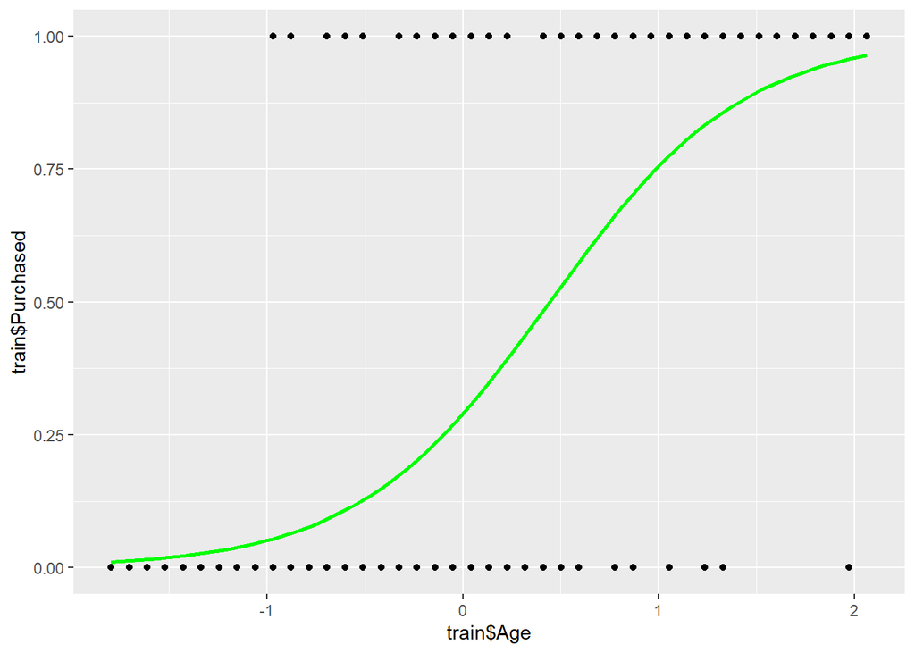

```r
library(ggplot2)
ggplot(train, aes(x=train$Age, y=train$Purchased)) + geom_point() +
      stat_smooth(method="glm", color="green", se=FALSE,
                method.args = list(family=binomial))
```

**Question 11 : Fit a logistic regression model of Purchasing the product in function of the Age of the user and its Salary.**

```r
model2 = glm(formula = Purchased ~ Age + EstimatedSalary, data=train, family=binomial)
summary(model2)
```

```
##
## Call:
## glm(formula = Purchased ~ Age + EstimatedSalary, family = binomial,
##     data = train)
##
## Deviance Residuals:
##     Min       1Q   Median       3Q      Max
## -2.9377  -0.5515  -0.1391   0.3717   2.2807
##
## Coefficients:
##                 Estimate Std. Error z value Pr(>|z|)
## (Intercept)      -1.0820     0.2171  -4.984 6.21e-07 ***
## Age               2.4591     0.3497   7.033 2.03e-12 ***
## EstimatedSalary   1.2455     0.2420   5.147 2.64e-07 ***
## ---
## Signif. codes:  0 '***' 0.001 '**' 0.01 '*' 0.05 '.' 0.1 ' ' 1
##
## (Dispersion parameter for binomial family taken to be 1)
##
##     Null deviance: 315.44  on 239  degrees of freedom
## Residual deviance: 163.87  on 237  degrees of freedom
## AIC: 169.87
##
## Number of Fisher Scoring iterations: 6
```

**Question 12 : Are the predictors significant?**  
The p-value of the Age and EstimatedSalary variables are below 0.05 which means that the null hypothesis can be rejected and our results likely did not happen by chance therefore the predictors are significant in this logistic regression model.

**Question 13 : Did the model get better by adding the EstimatedSalary?**  
By adding the EstimatedSalary, the model get better.

**Question 14 : On the test set, predict the probability of purchasing the product by the users using the obtained model.**

```r
Predicted_data <- predict(model2, test, typ = "response")
```

**Question 15 : We predicted the probability that the user will purchase the product. Now in order to compare our results with the real answers, transform the predicted values to 0 or 1 (1 if > 0.5).**

```r
Predicted_data <- ifelse(Predicted_data > 0.5, 1, 0 )
Predicted_data
```

```
##   4   5   9  10  14  15  19  20  24  25  29  30  34  35  39  40  44  45  49  50
##   0   0   0   0   0   0   0   1   0   0   0   0   0   0   0   0   0   0   0   0
##  54  55  59  60  64  65  69  70  74  75  79  80  84  85  89  90  94  95  99 100
##   0   0   0   0   0   1   0   0   0   0   0   0   0   0   0   0   0   0   0   0
## 104 105 109 110 114 115 119 120 124 125 129 130 134 135 139 140 144 145 149 150
##   1   0   0   0   0   1   0   0   0   0   0   0   0   0   0   0   0   0   0   0
## 154 155 159 160 164 165 169 170 174 175 179 180 184 185 189 190 194 195 199 200
##   0   0   0   0   0   0   0   0   0   0   0   0   0   0   0   0   0   0   0   0
## 204 205 209 210 214 215 219 220 224 225 229 230 234 235 239 240 244 245 249 250
##   0   1   1   0   0   1   1   1   1   0   0   1   1   1   1   1   1   0   0   0
## 254 255 259 260 264 265 269 270 274 275 279 280 284 285 289 290 294 295 299 300
##   1   1   1   1   0   1   1   0   1   1   1   1   1   1   1   0   0   0   1   1
## 304 305 309 310 314 315 319 320 324 325 329 330 334 335 339 340 344 345 349 350
##   0   0   1   0   1   0   0   0   1   1   1   1   0   1   0   1   1   1   0   0
## 354 355 359 360 364 365 369 370 374 375 379 380 384 385 389 390 394 395 399 400
##   0   0   0   0   1   1   0   1   1   0   1   1   1   1   0   1   1   0   0   1
```

**Question 16 : To evaluate the predictions, compute the confusion matrix. What do you obtain ?**

```r
library(caret)
matrix <- confusionMatrix(factor(Predicted_data), factor(test$Purchased))
matrix
```

```
## Confusion Matrix and Statistics
##
##           Reference
## Prediction  0  1
##          0 94 14
##          1 11 41
##
##                Accuracy : 0.8438
##                  95% CI : (0.778, 0.8963)
##     No Information Rate : 0.6562
##     P-Value [Acc > NIR] : 8.823e-08
##
##                   Kappa : 0.6491
##
##  Mcnemar's Test P-Value : 0.6892
##
##             Sensitivity : 0.8952
##             Specificity : 0.7455
##          Pos Pred Value : 0.8704
##          Neg Pred Value : 0.7885
##              Prevalence : 0.6562
##          Detection Rate : 0.5875
##    Detection Prevalence : 0.6750
##       Balanced Accuracy : 0.8203
##
##        'Positive' Class : 0
##
```

**Question 17 : Calculate the accuracy, specificity, sensitivity and the precision of the model.**

```r
accuracy = matrix$overall['Accuracy']
accuracy
```

```
## Accuracy
##  0.84375
```

```r
specificity = matrix$byClass['Specificity']
specificity
```

```
## Specificity
##   0.7454545
```

```r
sensitivity = matrix$byClass['Sensitivity']
sensitivity
```

```
## Sensitivity
##   0.8952381
```

```r
precision = matrix$byClass['Pos Pred Value']
precision
```

```
## Pos Pred Value
##      0.8703704
```

**Question 18 : Plot the ROC curve and calculate AUC value.**

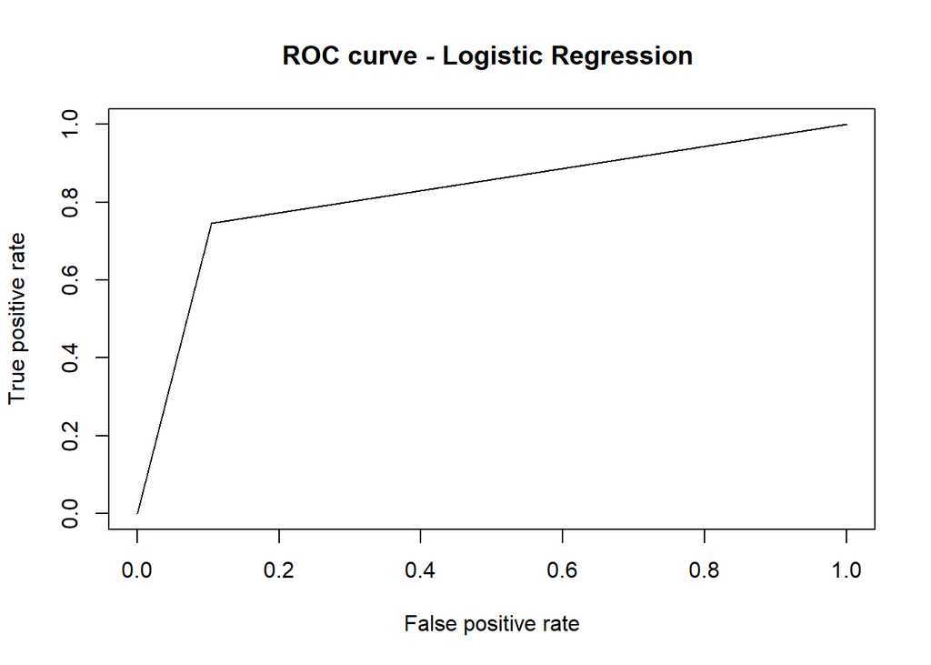

```r
library(ROCR)

pred <- prediction(Predicted_data, test$Purchased)

roc=performance(pred,"tpr","fpr")
plot(roc ,main ="ROC curve - Logistic Regression ")
```

```r
auc_ROCR <- performance(pred, measure = "auc")
auc_ROCR <- auc_ROCR@y.values[[1]]
auc_ROCR
```

```
## [1] 0.8203463
```

**Question 19 : Compare the AUC of the two models you fitted (one with only age and one with age and estimated salary) and plot their ROC curves in the same figure.**

```r
Predicted2 <- predict(model1, test,typ = "response")
pred_2 <- prediction(Predicted2, test$Purchased)

auc_2<- performance(pred_2, measure = "auc")
auc_2 <- auc_2@y.values[[1]]
auc_2
```

```
## [1] 0.8630303
```

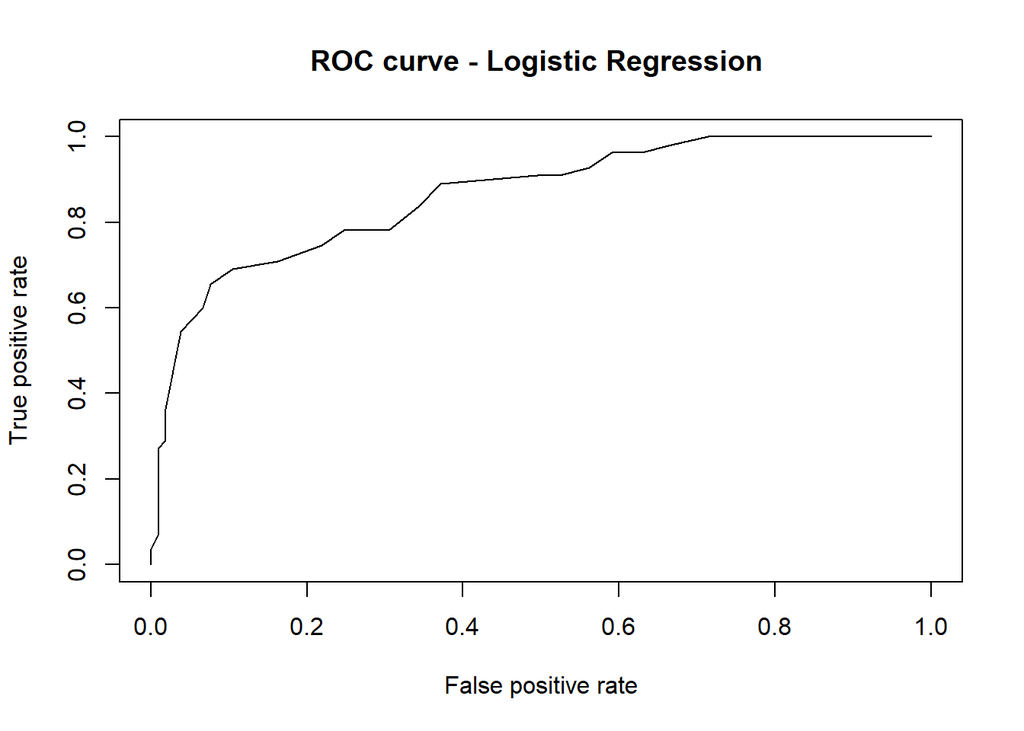

```r
roc_2=performance(pred_2,"tpr","fpr")
plot(roc_2 ,main ="ROC curve - Logistic Regression ")
```

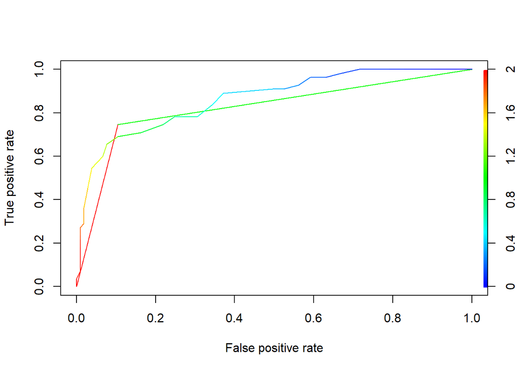

```r
plot(roc, colorize = TRUE)
plot(roc_2, add = TRUE, colorize = TRUE)
```